# 2022 Winter Data science challenge

Khusanbek Mukhammad Azim

12/09/2021

# Question 1

We first read in the data from the csv and check that we have all the columns.

```r
sneaker <- read_csv("2019_challenge_set.csv")
```

## (a)

Lets take a look at our data.

```r
sneaker
```

| order_id | shop_id | user_id | order_amount | total_items | payment_method | created_at |
| --- | --- | --- | --- | --- | --- | --- |
| 1 | 53 | 746 | 224 | 2 | cash | 2017-03-13 12:36:56 |
| 2 | 92 | 925 | 90 | 1 | cash | 2017-03-03 17:38:52 |
| 3 | 44 | 861 | 144 | 1 | cash | 2017-03-14 4:23:56 |
| 4 | 18 | 935 | 156 | 1 | credit_card | 2017-03-26 12:43:37 |
| 5 | 18 | 883 | 156 | 1 | credit_card | 2017-03-01 4:35:11 |
| 6 | 58 | 882 | 138 | 1 | credit_card | 2017-03-14 15:25:01 |
| 7 | 87 | 915 | 149 | 1 | cash | 2017-03-01 21:37:57 |
| 8 | 22 | 761 | 292 | 2 | cash | 2017-03-08 2:05:38 |
| 9 | 64 | 914 | 266 | 2 | debit | 2017-03-17 20:56:50 |
| 10 | 52 | 788 | 146 | 1 | credit_card | 2017-03-30 21:08:26 |

[output cut: 4990 more lines]

Notice that for order id 4 and 5 come from the same shop based on the shop id. I suspect that the average of the order_amount column was taken without accounting for the fact that the same shop can have multiple order ids.

Let us check this assumption by calculating the average of the orders.

```r
mean(sneaker$order_amount)
```

```
## [1] 3145.128
```

Here we get that the average order value is $3145.13 as first assumed.

## (b)

We can group all shop purchases together and then take the median of all their purchases. Since a couple of the shops have large orders, which skews the average, taking the median or excluding the outliers and then taking the average would also work.

Below we see what the AOV for each shop is.

```r
sneaker %>%
  group_by(shop_id) %>%
  summarize(shop_AOV = mean(order_amount)) -> shop_order

shop_order
```

|  | shop_id | shop_AOV |
| --- | --- | --- |
| 1 | 1 | 308.8182 |
| 2 | 2 | 174.3273 |
| 3 | 3 | 305.2500 |
| 4 | 4 | 258.5098 |
| 5 | 5 | 290.3111 |
| 6 | 6 | 383.5085 |
| 7 | 7 | 218.0000 |
| 8 | 8 | 241.0435 |
| 9 | 9 | 234.0000 |
| 10 | 10 | 332.3019 |

[output cut: 90 more lines]

## (c)

Next we find the median of the shop AOV to get to our answer.

```r
median(shop_order$shop_AOV)
```

```
## [1] 308.8898
```

The median order value is $308.89.

```r
mean(shop_order$shop_AOV[1:41]) + mean(shop_order$shop_AOV[43:77]) + mean(shop_order$shop_AOV[79:100])
```

```
## [1] 902.4913
```

# Question 2

## (a)

$\textbf{SELECT}$ ShipperID, count(*) from Orders

$\textbf{GROUP BY}$ ShipperID

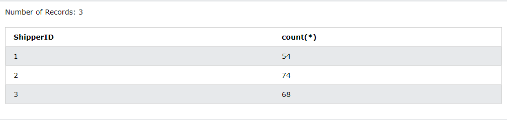

Speedy Express has Shipper ID of 1 shipped 54 orders.

## (b)

$\textbf{SELECT}$ OrderDetails.OrderID, OrderDetails.Quantity, Orders.OrderID, Orders.EmployeeID, Employees.EmployeeID, Employees.LastName

$\textbf{FROM}$ OrderDetails $\textbf{JOIN}$ Orders

$\textbf{ON}$ OrderDetails.OrderID = Orders.OrderID

$\textbf{JOIN}$ Employees

$\textbf{ON}$ Employees.EmployeeID = Orders.EmployeeID

$\textbf{GROUP BY}$ LastName

$\textbf{ORDER BY}$ Quantity DESC

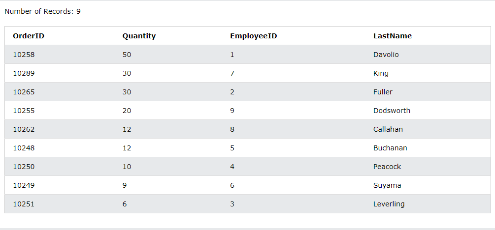

Davolio had the most orders.

## (c)

$\textbf{SELECT}$ Customers.Country, Products.ProductName

$\textbf{FROM}$ Customers

$\textbf{INNER JOIN}$ Orders $\textbf{ON}$ Customers.CustomerID = Orders.CustomerID

$\textbf{INNER JOIN}$ OrderDetails $\textbf{ON}$ Orders.OrderID = OrderDetails.OrderID

$\textbf{INNER JOIN}$ Products $\textbf{ON}$ OrderDetails.ProductID = Products.ProductID

$\textbf{GROUP BY}$ Country

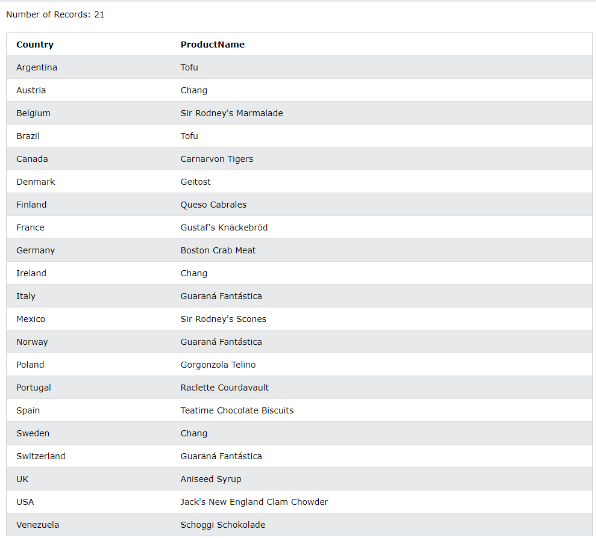

The most ordered product by customers from Germany was Boston Crab Meat.